# The world of Etharis

Lupus

Last updated: 2022-02-26

[interactive chart not shown]

# ♪ The Dreamland Troupe ♪

| Alin | Masq | Unit | Hallbjorn | Abraxas |
| --- | --- | --- | --- | --- |
| Lupus | Barth | Carmen | Crypton | Slowpoke |

# Etharis

## The Dreamland Travelers

### Info

*“To entertain with talent and looks is great, but to entertain with ones soul; that is magnificent.”*

**Headquarters:** None

Songs unsung, dances long forgotten and stories of man and monster none have ever laid their eyes upon; sure signs that the Dreamland Travelers are in town. This rag-tag band of individuals travel the lands of Etharis to spread their arts for the delights of others; and earn a pretty penny in the process.

As all strangers are, they are treated with excessive amounts of distrust by most; more so by those of the higher classes. To those who can’t afford regular entertainment, however, they are a welcomed sight and make for a colorful evening of entertainment at the low price of a few coppers.

The troupe is comprised of people from all nationalities and (former) walks of life; outcasts, runaways, the odd ostracized or down-on-their luck noble; all find a home under the wings of freedom. Those who find themselves a part of the troupe are inaugurated as family in a binding ritual that marks each of them as protected by the others: for the blood of the coven runs thicker than the water of the womb. It is in this ritual that a new member sheds their last name in favor of becoming a Dreamlander.

At the head of the Dreamland family sits matriarch Tessilia, an older woman who hails from Charneault. In her younger years, she and her friends joined a travelling caravan of merchants and used what skills as entertainers they had to get by. As time passed, more souls joined them until they had enough carriages to form their own caravan.

### People

#### Friendly faces

##### Mantazi

Wise Dark elf, filled with dualities.

##### Oona

Sweet granny who loves to cook

##### Skra

Cute bird who is social

##### Ting

Cute bird who is speedy

##### Tarvik

Strongman who is intimidating but kindhearted

##### Tessila

Owner of the Dreamland travellers

##### Tripp

Reliable but antisocial scout

##### Valerian Alhambra

Magician who is mysterious

##### Troupe

## Ostoya

### The Stillborn forest

#### Overview

At times of famine, one more mouth to feed can spell the end for an entire family. Giving birth to an illegitimate child, or gods forbid, the child of an outsider, could bring shame and accusation of familial betrayal or witchcraft to the parents of Ostoya. Sadly, there are many reasons for a child to be abandoned, each more heartbreaking than the last.

The stillborn forest received its name as a result of this very practice. Be it burying the corpse of an unwanted child or the improper burial of a stillborn infant, the stillborn forest is one that seems to be rife with decay, death and sadness.

##### Layout

The layout of the stillborn forest appears to shift constantly, making straying off the beaten path a dangerous affair. The wildlife is abundant and full of diversity, consisting mostly of wild game such as deer, rabbit and pheasant, but animals such as wolves, bears and crows are an ever present factor of this ecosystem.

Many of the trees bear occult markings, both carved and painted, as well as being adorned by woven figures of twine and straw. Most disturbing of all, perhaps, is the presence of single humanoid ears hanging from branches. They come in all sizes and colours and seem to be made up equally of left and right ears.

##### The Lady

The forest is also rumoured to be the home to an ancient being - far older than humans, older than the stone academies and the mages, older even than dwarves and elves. The folk who live in the forest have never seen her, but they know she protects them. It would seem that this is the case, as Weeping Pox has not reached the lands of Lunsk and Fallowheart.

If one listens to tales and stories, you will learn how to plea for help from the lady; such help always comes at a price, but the lady has the reputation to always keep her word. It is rumoured that the Lady helps those who are faint of heart out with unwanted offspring as well. This is how one begs help from the Lady;

“Find a child, young and innocent, and search out the Lady’s shrine—that is where the Trail of Treats begins. Set the child off on the trail and it shall follow its sweet track and find the Good Lady. The child will never want for anything ever again, for the Lady is kind and generous. Standing before her shrine, pronounce your request and the Good Lady will hear, for she sees and hears all that takes place in her demesne. If you made the offering as it must be done, your supplication will be heard.”

#### Lunsk

A small town, though one of the largest in the forest, walls fortified on the western side, the forest surrounding is thick with monsters and undeath. They export lumber, namely **Sapwood**, found bordering lake Ostruva Mare.

The citizens distrust outsiders.

##### Town square

A beautifully kept garden lies in the town square, diligently kept by an old woman named **Theruoa**.

The plants that grow here are varied, some are edible, some inedible, some poisonous. A deep rooted plant seems to be having trouble, sagging.

##### Tavern

The tavern is a large one, seeing action more in the eve, with some gambling taking place then. They serve a rare drink called Sapwood mead, which is sweet and syrup-y.

##### The Black Circle

The towns woodcutters are called the **Black Circle**, a lumberjack druidic circle.

They are recently making a new holy tree, a pale one surrounded by large white rocks, remarkably vibrant and alive.

The mayor suspects them of being hostile, currently no evidence.

They worship **the lady** giving wooden trinkets in her honor

The Druids wish to rid the land of undead with the use of a weirwood tree. They are not afraid of getting their hands dirty with killing off those who oppose them.

###### Weirwood tree.

Sucks up magic from the environment, storing it at its roots. Over time its green leaves turn red and it sometimes grows a face. The ground is extremely well maintained

Sucks up necrotic energies, supposedly to reduce amount of undead in the area. This however would throw an unbalance into the beast/undead symmetry.

##### Quests

- Look into a kid missing (maybe given to the lady?)
- Investigate woman’s husband, who has been sneaking out at night. (probably cheating or doing necromancy)
- Look into kid whose imaginary friend might be real
- Cyclops north of town, hunt it down

###### Completed

- Investigate scratching under floorboards (probably rats?)
  - found cave under floor.
  - was full of Kruthics(insect like monstrosity) who were nesting there
  - Eliminated the nest and eggs
  - found blacksmiths neighbor dead
- wanted poster
  - The woman has been found, she was being hidden by the druids.

#### The great sequoia tree

Along the road from Lunsk there lay a gigantic sequoia tree. A trunk wider than 15 people holding hands. It’s top spreading deep into the clouds, not even the lowest of branches visible from the ground.

This great tree has been corrupted. In its base lay a split and in it’s hollow trunk lay a chamber of evil. A place of ritual devoted to the lady of the forest. Here lay bones of countless men and women, some older some newer. Burnt.

The corruption of the tree driving a wedge within the earth several hundred feet long. if not a mile.

Alin has taken 3 seeds from this great tree, planting one of them near it. Certainly it shall know the life this one did one day.

### The Black Myre

In the eastern portion of Ostoya, near the Dire Shore, a forest of aspens, willows, and oaks give way to fetid wetlands full of slow-moving, brackish water.

The Black Mire has not been thoroughly explored. Most cartographers are forced to turn back due to the treacherous terrain, bad weather, illness, or swamp monsters that accost them as they travel. Many an adventurer has met their end in the swamp’s murky embrace.

Coincidentally, it is the home of the illusive Blackmire Lizardfolk. Due to their nomadic lifestyle in such a hard-to-traverse terrain, their physiology and society is largely undocumented.

Stories persist that covens of hags dwell within the far reaches of the swamp, and that they are willing to make bargains with those who come searching for them.

One must beware when dealing with hags, however - often the payment they demand is something one is not willing to part with.

## Gräffendam

### The high city

The lofty walled sity of Gräffendam sits above the dam by the water reserve.

A place for the people of high society to travel to. As it is placed by both Ostoya and the Burag it is influenced by both yet notably has both sunlight and more than a handful of half elves.

### Weirwood island

#### Location

Located within the lake above Unterdam is a massive weirwood tree, spanning more than a thousand feet in height.

### The Purple Bookworm

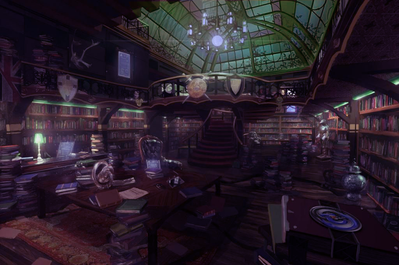

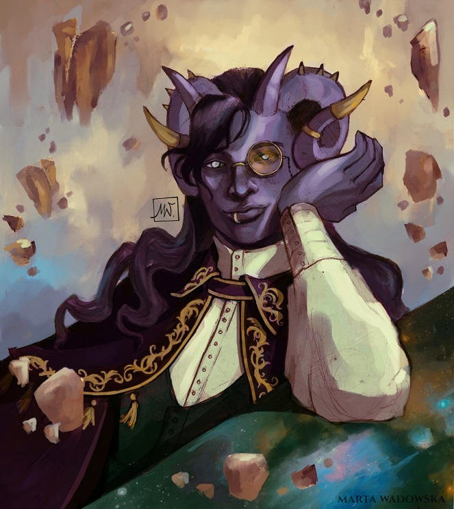

Ransdir Falconer, a middle-aged optimist of a tiefling with purplish skin tone, collects, buys, and sells books in his cozy little bookshop. One can find many types of books from Morencian love novels to encyclopedias on his tightly packed and well-organized shelves. Ransdir also serves tea to anyone who cares to stay a bit to read in one of his comfy armchairs.

### Koloss’ boots

### Unterdam

A dingy den below the obsidian dam of Gräffendam, once more magnificent. Now place for those unfit for high society and thus driven even deeper into poverty

## The Domains of Dread

This world is not all there is…

# Alin

## Bio

### Data

#### Bio

| Info | Description |
| --- | --- |
| Age | 19 |
| Alignment | CG |
| Pronouns | they |
| Heritage | [Half Vistani](https://www.worldanvil.com/w/etharis-mikkow/a/half-vistani-article)(mother), half human(father) |
| Favorite Color | Red |
| Languages spoken | Common, old Ostoyan, Patterna, Druidic |
| Tools | Herbalists kit, Cook’s utensils, Land Vehicles and Drums. |
| Birthplace | Ostoya |

#### Stats

| Info | Description |
| --- | --- |
| Strength | 8 |
| Dexterity | 12 |
| Constitution | 10 |
| Intelligence | 6 |
| Wisdom | 20 |
| Charisma | 14 |
| Dark powers | 10 |
| Class | Druid (shepard) |
| Level | 2 |
| Background | Folk Hero |
| Divination | If a job is worth doing, it is worth dying for: Increase your Wisdom or Constitution by 1. Reduce your Strength or Charisma by 1. |

#### Backup

| Info | Description |
| --- | --- |
| Strength | 15 |
| Dexterity | 15 |
| Constitution | 6 |
| Intelligence | 16 |
| Wisdom | 13 |
| Charisma | 16 |
| Dark powers | 10 |
| Class |  |
| Level | 2 |
| Background |  |
| Divination | The wise learn from the deaths of others. Your Acrobatics and History skills each increase by 1. |

## Memories

### Birth and heritage

#### Mom

Name: Isabela Tselikov

She taught me the importance of people, and through her i came to understand serving to bring joy to others brings peace to oneself.

My mother has always been a servant, not of anyone in particular, but of a joyous life. She brings happiness wherever she goes. Compassionate, kind, and caring. Her main job in the Tselikov band is as a dancer. A spectacle of technique and flair, she flies across the stage in a perfected flow of flourishes of blade, twists and twirls, like a river or whirlpool. Unmatched in the way she sways and swings across the stage. Enticing you to lean in, as if this whole dance were for you.

#### Dad

Name: Ronan Byrne

My father, a druid who worked completely selflessly for life itself. He taught me to strike balance and listen attentively both to people and to the world. He showed me how connected the world is, and how it is just as much a part of me as I am of it.

#### Shae

Name: Katarina Tselikov

Honored elder, though distant from me. She showed me mercy when times looked dark. She is truly worthy of being Shae

### Prelude

### Early childhood

Born to a union between a Vistana dancer and druid. Alin was not accepted into the midst of the vistani, though father almost a honorary vistani, someone with muddled blood would be allowed to stay if they don’t prove to be a problem.

### Raised different

The children I played with when i was younger stopped, inviting me, or even including me in their games and circles. As such i played with the animals, either with Ronan who taught me about them, or on my own, learning how they play. I spent most days with the animals. The other time, I spent with my parents, telling stories, playing games or merrymaking. Sometimes dancing with my mother or hunting and gathering with my father.

### Stories neath the stars

During his life, Alin has had many nights filled with stories and wonder underneath the stars, some from his father, some from vistani when the whole tribe gathered.

#### The powers that be (Ronan)

“There are aspects of powers beyond us all around. From the flame that eats our wood and heats our winter nights, to the land that stays firm under feet yet gives way to roots and caverns. They all have something to say, if you but look close enough and learn to listen.”

#### Preaching trees (Ronan)

"For me, trees have always been the most penetrating preachers. I revere them when they live in tribes and families, in forests and groves. And even more I revere them when they stand alone. They are like lonely persons. Not like hermits who have stolen away out of some weakness, but like great, solitary men, like composers. In their highest boughs the world rustles, their roots rest in infinity; but they do not lose themselves there, they struggle with all the force of their lives for one thing only: to fulfill themselves according to their own laws, to build up their own form, to represent themselves. Nothing is holier, nothing is more exemplary than a beautiful, strong tree. When a tree is cut down and reveals its naked death-wound to the sun, one can read its whole history in the luminous, inscribed disk of its trunk: in the rings of its years, its scars, all the struggle, all the suffering, all the sickness, all the happiness and prosperity stand truly written, the narrow years and the luxurious years, the attacks withstood, the storms endured. And every young farmboy knows that the hardest and noblest wood has the narrowest rings, that high on the mountains and in continuing danger the most indestructible, the strongest, the ideal trees grow.

Trees are sanctuaries. Whoever knows how to speak to them, whoever knows how to listen to them, can learn the truth. They do not preach learning and precepts, they preach, undeterred by particulars, the ancient law of life.

A tree says: A kernel is hidden in me, a spark, a thought, I am life from eternal life. The attempt and the risk that the eternal mother Eana took with me is unique, unique the form and veins of my skin, unique the smallest play of leaves in my branches and the smallest scar on my bark. I was made to form and reveal the eternal in my smallest special detail.

A tree says: My strength is trust. I know nothing about my fathers, I know nothing about the thousand children that every year spring out of me. I live out the secret of my seed to the very end, and I care for nothing else. I trust that Eana is in me. I trust that my labor is holy. Out of this trust I live.

When we are stricken and cannot bear our lives any longer, then a tree has something to say to us: Be still! Be still! Look at me! Life is not easy, life is not difficult. Those are childish thoughts. Let Eana speak within you, and your thoughts will grow silent. You are anxious because your path leads away from mother and home. But every step and every day lead you back again to the mother. Home is neither here nor there. Home is within you, or home is nowhere at all.

A longing to wander tears my heart when I hear trees rustling in the wind at evening. If one listens to them silently for a long time, this longing reveals its kernel, its meaning. It is not so much a matter of escaping from one’s suffering, though it may seem to be so. It is a longing for home, for a memory of the mother, for new metaphors for life. It leads home. Every path leads homeward, every step is birth, every step is death, every grave is mother.

So the tree rustles in the evening, when we stand uneasy before our own childish thoughts: Trees have long thoughts, long-breathing and restful, just as they have longer lives than ours. They are wiser than we are, as long as we do not listen to them. But when we have learned how to listen to trees, then the brevity and the quickness and the childlike hastiness of our thoughts achieve an incomparable joy. Whoever has learned how to listen to trees no longer wants to be a tree. He wants to be nothing except what he is. That is home. That is happiness."

### Famine (alin’s first spell and focus)

There was a time where I saw strife. It was when we were traveling deep in barren lands. As winter struck crops would not yield and the very earth was left defeated. We had long since emptied our stores of food and made use of our cattle.

Our celebrations became sparse, people rarely having the energy to spend on their way of life. I saw the people I know become thin and pale, filled a constant gnawing in their body. More than a handful were overtaken by illness as their bodies focused on conserving energy.

Ronan and I set off to find food as we had since food became sparse. The lands, though unforgiving, still had some herbs whose poisons they could neutralize and old root vegetables still buried in the earth. This would be enough, were there but a few people, but there were too many mouths to feed. Ronan and i would return with the meager food they managed to secure and along with what others got, we would cook it and ration it to those that needed it most.

This would all change however on one excursion however. As we were out gathering plants, something caught my eye. A glint of green in a dying place. Pushing past the dead things, entranced by life so radiant it was painful to look at after so long. A powerful tree, standing firm and strong in the ground, with birds nesting and leaves bunched up in neat clumps. I came to recognize this as mistletoe. Stepping forth i placed my hand against it’s trunk, gliding it against the rough bark. As I admired the tree my hand moved along the wood, to a branch and then a clump of leaves. As my fingers brushed through the sprigs of mistletoe I marveled in half prayer to the tree, of its strength and virility, of its sacred place among these woods, of the birds that found themselves sustained by it and the significance of such a thing.

I felt it, the bountiful life that flowed within, a warm solidarity that wished to share itself, not unlike the warmth of being loved unconditionally. I knew it felt our strife as surely as I had felt it right now. I pressed my forehead against the rough bark to thank it, and as i did so, i felt a shifting in my hand, now gently clasping one of the sprigs. As i drew it away I found out why the tree had led me to it. A gift of ten small berries and a sprig of mistletoe to which they are attached.

Once I returned to my father, I showed him what I found and told him of what I saw. He merely wrapped his arms around me in an embrace more enthusiastic than looked fitting a man of his age. “Alin, my child. This is remarkable, you have been chosen, seen worthy by the mistletoe tree. This is certainly only the beginning of your connection to the land. And what’s more, you may have just saved us from starving.”

We returned post haste, and surprisingly enough, with a few pointers from Ronan, I was able to recreate what happened before, producing ten more berries. Smiling proudly, dad and I added the berries to the pot. It turns out, such berries are nourishing beyond belief, and with added ingredients gathered for structure and flavor, we were able to strive off the worst of the famine.

In the end, the time spent yearning for food, followed by being able to cook delicious meals, got me hooked on cooking. Since that winter, I have continued cooking, though the famine is long past. I find making good food can often brighten any day, and certainly those who are hungry.

### Tatoos

Alin’s tattoos are more than meets the eye, the red twisting twirling and eye catching shapes are stories scrawled on their host in druidic. Most would not even recognize them as script of any sort, the patterns more aesthetic and loosely structured than one would expect of writing. They tell stories of old, they tell fairy tales of spirits and they tell lessons of the land. Though written down, druidic is not a simple language, it is written in tongue which needs to be interpreted, parables and prose woven in one on Alin’s skin. They may read the same passage a thousand times and never repeat it in meaning, yet learning from it each time. Such is the gift they were given by their father and guide, though he never revealed where he learned this pattern, or even how much of it he understood.

### Arson is ill advised (worst memory)

When Alin was learning to understand the flames, tracing a particular story on the back of their hand, they found out how alive flame really is, responding to their guidance. Mesmerized by the ebb and flow, they felt the hunger of the flame, to grow and eat, to be more of itself. It the feeling felt like Alin’s own and in a way it was, the boundary of the world and the edges of the separation getting hazy. Alin was for a while swaying in tandem, a part of the flames, and without noticing they spread their arms and the flame was sated as the flame climbed up the tent. The trance was only stopped with vistani stepping in and grabbing Alin. The following was a tough time, as Alin was brought in-front of the elders of the band to stand trial for the seemingly deliberate arson.

The elders of the tribe consulted and asked Alin why she burnt down their family tent and started several more. Alin, ever truthful told them, the hunger of the fire was overwhelming. Even as the judged said this they knew the flame was not to blame, it was Alin who lost control, of themself and the flame. The elders conulted once more and it seemed ever clearer that this youth was not to stay, not a vistana and not done anything special to earn a stay. Alin listened to this with a sullen expression. Resolving to accept any punishment without complaint.

But soon a voice spoke out from midst the others, the Shae Katarina Tselikov, one of the most respected vistana in the tribe. She told the others that this was Ronan’s child, and a gentle one, this was the first time any such thing had happened. She was close to Ronan, him having saved her and several others many a time, this was only Alin’s first offense. And she managed to convince the others that if this was the only one, then Alin could stay, for now.

### The stench of death (folk hero event)

While we were camped in *The Stillborn Forest*, doing our standard rounds of merriment. I became aware that something was not right, something smelt noxious. The sickly sweet smell of rot and decay creeping in from somewhere. Being covered by the sizzling food on the fire, we had not been camped here long enough for our wares to rot, so this stench was coming from elsewhere.

Closing my eyes, i focused on the smell, and the eyeless sight, A smell of rot familiar to the forest, but focused. The foulness inching down my spine, with the scent of undeath nearby, a powerful, gut churning wrongness. If it is this strong, then there’s no time to waste.

**“Undead! Pack your things and move!”** I yelled, spotting shifting movement in the woods, large hulking and lumbering. Tossing my bag on my back i pulled out three pebbles and prayed they strike true. The mass emerging from the forest edge, i let loose one of the stones. *Hit* I had its attention. The others, fleeing hastily, retreated to the *vardos*. The stench got thicker as the thing emerged, thick vines like the thick roots of a white oak, drenched in green rot and housing several carcasses, with bulbs of flowers dotting the top like a mockery of nature. Looking around to find a path clear of people, I saw the road ahead blocked, where people were gathered, trying to remove a tree that fell in the night. I could not let this thing get there, where the only way out for us would be death.

A massive vine snapped out at a nearby cattle, nearly breaking it in half as it wrapped around the animal and drawing it into itself, the vines dragging it along the ground towards me. It is slow. I can use this. I let loose another stone, speeding opposite of where the others fled to draw it away. Another toss and i had its undivided attention.

My feet pulling me to the edge of camp, my wrist was grasped. My dad, with a serious expression. He told me to get to the others and out of here. “The road is blocked, they cannot clear it. You’re the only one who can.” I said pulling my hand free and another 3 pebbles out of my bag. “I can keep out of its reach and draw it away, it is slow.” i stated, turning my head back to the creature now less than a stone-toss away once more. Ronan grimaced as he looked past the creature at the mass of people. “You better get back in once piece, I know you will.” He said leaning in to give the side of my forehead a kiss. “Meet us when you get clear of this thing.” He said resolutely, trying to hide his fear, as his form shifted to that of an Ox, not the fastest beast but certainly strong enough to remove the blockage.

As my father cleared from the area i ran backwards towards the woods, hitting one of the bulbous flower-pods on the creature, it was still following me, good. Turning to run to the back, I almost tripped on something shiny. I recognized this sheen of blade, hilt red with flourishes. Someone had dropped Mesmerelda, No-one was here to pass it to, and i certainly wasn’t going to let it get left behind in the dirt, forgotten, so i grabbed it as i continued my assault.

It followed me into the woods, and for the next dozen of minutes i made certain to keep clear of its powerful vines, finally finding an opening to flee when i passed a patch of trees so close together it could not pass.

I looked for the road, I looked for my family, but ended up on a different path. I never did find them again, but I’m certain I will one day.

### Poison

The cloudy sky beat like a drum with the concussing bursts of thunder. Alin’s head pivoted left and right, as if tracing a flash across the horizons. They were laying on the ground, hands and legs resting where they fell. This is how Isabela found her child. Pale, feverish and disorientated. Before she knew it, she was already over them, hand on their cheek. “My dear. What happened? Are you ok?” Their head now propped up, Alin’s eyes attempt to focus on her. Who? This person, I think know them. The flashing thunder feels like an attack on their mind. “Ma-” they say, recognizing the veiled lady caring for them.

### Vistani blade Mesmerelda

"Long favored by street performers, this vistani blade was forged to dazzle audiences. A strip of bright red cloth has been wrapped around its hilt, winds through the back of its blade, and ends in little golden coins that dangle from it. These coins jingle and sway as the blade is swung, producing a sound similar to a coin purse being rattled.

Mesmerelda was originally carried by a troupe of traveling vistana but in the years since it has been passed from sword dancer to magician, and beyond, in its travels, during which time it has been an integral part of many daring exhibitions of finesse and skill. Despite its storied history, the blade has never forgotten its roots among traveling folk."

#### Mesmerelda

### A Dreamy encounter

## Personality

### Characteristics

#### Personal rules

“I would never hurt an another for my own gain.”

“I will try to feed the starving however i can.”

“I will aim to help people in being true to themselves”

“I will point out self deceptions wherever I may see them”

#### Goals

##### Major

Listen to the old teachers of the world

Bring people joy

Help those who are struck by famine gain more food.

##### Minor

Learn to perform better

See all the strangeness of the world

Return Mesmerelda to the clan

#### Personality trait

If someone is in trouble, I’m always ready to lend help.

The pain we share is equal one is not worth more than another.

#### Ideal

Respect. People deserve to be treated with dignity and respect. (Good)

#### Bond

I have a family, but I have no idea where they are. One day, I hope to see them again.

My troupe is precious to me.

I have trouble keeping my true feelings hidden. My sharp tongue lands me in trouble.

I will not stand by if i can stop an injustice.

I easily forget things like long names and complicated words.

### Answers to the questions

#### Physical description

Alin is of average height, black curly hair with ashen wisps. They usually wear clothes similar to those of most Vistana, but what clearly separates him from them is the red tribalistic tattoos that cover their body from toe to Forearm. To almost everyone these tattoos appear decorative and floral. But to those versed in druidic these are stories, prairs and blessings.

#### Social class

Being born into a band of vistani, Alin has never experienced either lucrative luxuries, nor horrible poverty. They have taken to viewing overindulgence as a sin and ignoring others suffering as a horrible thing to do.

#### Parents and family

Alin regards their father and mother as close family and confidants.

#### What sort of activities did you partake in, growing up?

Alin spent most of the free time in the day, helping Ronan forage and found a passion for cooking. They didn’t get to play much with the other kids, but was still able to participate in group music and dance.

In the evenings, The three told stories to each-other, either made up or experienced. Isabela always knew what stories to tell when Alin was feeling under the weather, either from being bullied, or seeing the sorry state of the people they passed.

#### Do you have distant family in other regions?

The band and Alin’s parents are still out there somewhere… hopefully.

#### Non-Familial relationships

The elders of the tribe rarely regard Alin, a good kid, but not one of them. Alin’s peers have cooled from their past of exuding Alin from everything, but they don’t ask either. Alin treats the animals that he gets close to as well as any people.

#### Did you have any pets growing up?

Alin Spent a lot of time with the horses and other animals that lived in the Band, crying whenever one of them died. They liked playing with Ronan’s familiar on the rare occasion that it was summoned.

#### What is your favourite memory?

Sitting on my fathers lap, playing the drums and singing while my mother was dancing on stage to our music, It felt like it lasted forever, though it lasted only the evening. Laughs were had, songs were shared and it felt like all the problems of the world drifted into nothingness.

#### What is your worst memory? Who was involved in it?

When Alin messed up once, almost getting the others to throw them out of the band completely, luckily they had mercy and Alin was allowed to stay.

#### Your personality - Who is your character? What makes them tick? What are their core beliefs and how has the world shaped them into the person they are today?

Alin is an extremely empathetic individual, they are spurred forwards each day with the drive to see the world and all in it. They are driven to help those who are suffering, especially those whose suffering is inflicted unfairly. If only Alin could help them or at least offer comforts of food or change of mind.

#### Fears

- Having to watch without being able to help when a loved one suffers
- Undead, they are uncaring unfeeling and more horrible than the worst of beasts.
- Being buried alive, or at all

#### Birthday

17th of Summertide

#### Where did you pick up the skills for the class you’re starting as?

My father, Ronan, taught me all I know of druids, herbs and animals. Though Alin always had a knack with animals, spending more time with them than other kids.

#### What is your view on religion and magic?

Religion:

- Finding the strength to carry on for a better day is important, but not to demonize those you disagree with.

Magic:

- Magic is to be used without selfish intentions, to bring balance, heal and protect.

## Relationships

## Prairs and spells

### Spirit totems

- Bear:
  - Ox: Beast of Burden, lend us your strength
  - Bear: Beast of Bear, lend us your hide
- Hawk:
  - O’ Hunter, O’ Hawk, lend us your swiftness
  - Raven of cunning, Lend us your wit.
- Unicorn:
  - Lord of the forests, give us aid
  - Noblest of steed, your help we heed

### Spells

Magic stone

- May you return to Eana, bring along their strength.
- May you strike with the might of a boulder
- Heart of mine, strike out with blame. Take from me and earth in same.

Healing

- May you remember as you once were
- Your body is broken, but with your spirit I will mend it
- Bind the tears of flesh and bone: Leave the sick to health alone.

Entangle:

- Flora heed my call to you, grow from sapling, entwine here though.

Faerie fire

- O’ spirits that are made on pyres, grow and show this place a fire.

Fog cloud

- Oh Crone and smith, doth heed my plea, mix in mist and let it be.

Goodberry

- Mother earth, a call of babe, grow and nurture, life do save.

Hold person

- You and I are one, you see. I hold my heart and you won’t flee.

### Dreamland travellers

#### The Dreamland Troupe

# Bestiary

## Contents

| Beasts | Undead | Monstrosities | Fiends | Fey | Abberations |
| --- | --- | --- | --- | --- | --- |
| Natural creatures, animals. | Creatures born of undeath | Creatures born from the undead, with a lust for life. | Devils, demons and the infernal | Tricksy creatures of the feywilds | creatires from beyond this world |

## Beasts

## Undead

### Corpse flower

Slow and lumbering, the stench of death fills the air. Large and unsightly, they release undead from their bodies and hunt for living flesh. The best course of action, to run.

### Vampires

They suck blood, they dread the sun. What more is there to say about these dreamy bastards.

## Monstrosities

### Giant boar

Charges, avoid being in an open area.

### Kruthik

Fought 1 adult and 6 children

Kruthiks are a strange type of giant insect with sharp teeth and claws.Their carapace is thick and provides heavy protection. They are effective in groups and can dig through the solid rock.

They nest in large yellowy-greenish vine like structures in caverns, their eggs look like rocks upon the root-like things.

In combat, do not engage more than one at a time, try to kill small ones first, steer clear of cavern openings they could ambush you from.

### The Bandersnatch

> With Jaws that Bite, and Claws that Catch A Vicious Tail that goes Snicker-Snack, Beware my Dreamlanders, Beware the Frumious Bandersnatch

The Fruminous Bandersnatch a six legged creature. That speeds in the wilds of Ostoya, they frighten their prey and dig their teeth into them.

# Bits of lore

## Countries

### the Valikan Clans

**Languages:** Imperial Norm, all dialects of Primordial, Giant, Orcish (Rare)

#### Thrull

#### Kandar

### the Bürach Empire

**Languages:** Imperial Norm, Lower-Bürach, High-Bürach, Raulish, Valikan

Founded by emperor Leopold

#### Altenheim

#### Nordenland

#### Rauland

#### Unterland

### the Ostoyan Empire

**Languages:** Imperial Norm, Ostoy

#### Soma

#### Raevo

### The Charneault Kingdom

**Languages:** Imperial Norm, Charneault, All Elvish Dialects, Sylvan

#### Tol-Leyemil, the Last Elven City.

### Castinellan Provinces

**Languages:** Imperial Norm, Castinellan, Draconic

#### Toletum

#### Faro

#### Therpena

## The Gallimaufry Deieties

The old spirits worshiped since long ago.

### Entropic

#### Death

The end, peace, scilence secrets, protector of the natural cycle.

#### Frostelle

The peace of death, the wisdom that comes with impermenance, acceptance.Temperance, patience and determination.

#### Night

Xonim

Once human, now goddess of darkness, magic and power, protector of tieflings.

Xonim’s bonds neutralize magic.

#### Storm

the Liberator

Once a human conqueror of sheer will and might, not even death could take him as he ascended to godhood along with his mother Xonim.

### Harmonic

#### Blacksmith

Te blacksmith, defends those who defend society, leans towards the rule of law.

#### Flora

Belle,

The gentle yet wild power of nature, she brings joy , luck and relief. She supports the brave and endures.

#### Maker

The fool, The one who creates, the wellspring of inspiration and creation of all its aspects, horrid and wondrous.

Supports the exploration of self and world.

#### The tryad

##### Nyctimus

The youngest shy brother, clever and mischievous. those who are cunning, druids, rogues and shamans follow him.

##### Solimar

The red blood maiden, patron of lycans, berserkers and riser of bones. Fearful reverence through battle. She supports the acting of revenge, acting over words and chaos.

##### Pram

The maternal one, the lover. Yellow moonlight. She cares for the resting, she supports you like a mother with a nurturing hand, hoping you care for others and others for you.

Patron of clerics, fighters, merchants and paladins.

#### Eana, the starstag, the great tree (the world)

The oldest divinity, the creator of this world, close to those who live with the world.

no one has heard of Eana granting prayers, only sometimes lends powers to druids and rangers. For druids, Eana is the balance required for all forms of life.

## Druids

### Sacred Plants and Wood

A druid holds certain plants to be sacred, particularly alder, ash, birch, elder, hazel, holly, juniper, mistletoe, oak, rowan, willow, and yew. Druids often use such plants as part of a spellcasting focus, incorporating lengths of oak or yew or sprigs of mistletoe.

Similarly, a druid uses such woods to make other objects, such as weapons and shields. Yew is associated with death and rebirth, so weapon handles for scimitars or sickles might be fashioned from it. Ash is associated with life and oak with strength. These woods make excellent hafts or whole weapons, such as clubs or quarterstaves, as well as shields. Alder is associated with air, and it might be used for thrown weapons, such as darts or javelins.

Druids from regions that lack the plants described here have chosen other plants to take on similar uses. For instance, a druid of a desert region might value the yucca tree and cactus plants.

## Vistani lore

- Patterna - Vistani language
- Giomorgo - A half Vistani
- Giorgio - Someone who is not Vistani. A general term for outsiders.
- Giogoto - An outsider who has done something so profound, they’re basically honorary Vistani. They’re accepted as one of the Vistani, though they weren’t born one.
- Shae - a generic term for an honored elder.
- Raunie - A Vistana with an exceptional gift for seeing the Threads of Fate.
- Remanio - Vistana who has left their tribe
- Lunatio - or moon madness, irritable in the day. Frolicking at night
- vardo - a horse-drawn wagon

## Witch Sight

While all creatures are connected to the weave, only those with strong magical abilities are capable of manipulating and reading it. All people born with the talent to work magic have some degree of witchsight that can be developed and expanded with training so the spellcaster can actually see the ebb and flow of magic, witness the scintillating colors of the Weave’s energy in its raw form, and be better able to harness it for the casting of spells. Having the ability to sense magic enables magisters and their ilk to better control the energies they wield. Aside from its utility, witchsight also reveals an abundance of odd manifestations, eerie phenomena, and sometimes glimpses of the future and the past. Common applications can be, but are not limited to;

Detecting the present of otherworldly beings or other magic casters Detecting (unusual) magical phenomena such as areas where the flow of magic has been disrupted or otherwise changed. Finding the exact location of a being, place or item that is channeling magic. (Imagine a weaker detect magic) Finding a person whose signature you are familiar with within the range of your Witch Sight. Your Witch Sight extends up to 10 times your Wisdom Modifier in feet (Minimum of 5 feet). Unless you possess the Witch Hunter talent, your Witch Sight is limited to a feeling, rather than seeing something physical. There are several DCs / tiers of gaining knowledge from a reading, increased or decreased by factors such as;

Attempting to use your Witch Sight through a wall or other obstruction The presence of other strong magic casters Lingering residues of magic casting Attempting to zero in on a particular strand of magic or person in a busy place Unless you enter a region that has a particularly strong magical presence or a thin membrane between the material world and the weave, you will not experience much from your Passive Witch sight.

# Session notes

## 1

Mask: Priscilla Montegue

lunsk,

Small town, gated on the west. Fortified town, the forest is thick with monsters and undead. The citizens distrust outsiders. They export lumber, namely Sapwood, found bordering lake Ostruva Mare. The towns woodcutters are called the black circle, lumberjack druidic circle.

Seems like they all respect druids with many druids amoung the townspeople.

Rumors:

- Vicious monsters and undead prowling the stillborn forest, many people have disappeared over the years.
- Sapwood is said to have precious alchemical properties.
- The leader of the black circle Sanrial is being kept from being elected by Evyriel using the militia.
- Evyriel Lied to the local militia, the Torta.
- The villagers practice necromantic rites.

Town square plants: Edible, inedible, poisonous. Beautifully kept by an old woman who appreciates nature, Theruoa.

Deep rooted plant sagging more than others.

Tavern:

- Sapwood mead, syrup-y
- Wood elf druid bar maid

Quests:

- Investigate woman’s husband, sneaking out
- Missing kid.

A gigant boar came in rushing after two guards, can it be persuaded to leave?

## 2

Mask: Priscilla Montegue

Killed giant boar which turned out to be a monstrosity from the forest.

Evyriel is suspicious of druids since they don’t have trouble in the forest

Evyriel angrily monologues to Sandriel about people in danger.

The tree pales in comparison to the new tree, i’m sure it’ll be done in no time.

Meek, the alchemist

- void coal (mastercraft venom clanse tea) 40gp
- artisans charcoal 1gp a bag

the floorboard scratching comes from a cave.

## 3

Mask: Priscilla Montegue; Masq(after being downed)

Abraxas was scared but performed bravely.

cave:

Jewlery: 30gp;

Carved out by some creature with sharp claws

long vine-y tree rooty tendrils, through the ceiling, with somewhat bulbous parts, eggs of Kruthiks.

Kruthiks, large insectoid creatures have made a nest and started tunneling behind the blacksmiths house.

Big mama loot:

6 spikes (0.5 slot daggers) Carapice armor (can be crafted into a medium[up to breastplate] or heavy [up to splint] that weigh half as much])

Druidic circle new holy tree: pale colored sapling, surrounded by big white stones,

Blonde lady at the middle, with people surrounded by the black circle (the wanted poster).

Druidic concept, ancestors of the land. Veneration of being born of the land and what it has given them.

## 4

Masq: Priscilla

Weirwood tree.

Sucks up magic from the environment, storing it at its roots. Over time its green leaves turn red and it sometimes grows a face. the ground is extremely well maintained

Sanriel: the guard encroached on the boars territory, causing it to get enraged.

Evyriel: Things have recently gotten a lot worse, the forsest is unsafe.

Wanted poster: woman with blond hair hiding around with the druids.

something gold from the sky, a piece of paper, like fish scales, a ticket hits Alin’s face

LEVEL UP!

## 5

Masq: Ella

Starts with performance

Many people came:

Pyke the demigryph, size of a mastiff.

Competition of mallet rock, Hallbjorn won

Abraxas wooing elf woman, or other way around.

## 10

walking back from the troll debacle when the party noticed a few quails. Masq upon seeing them shot 3 in a single arrow.  
After which the party met up with a unicorn, who ‘acted slightly sus’. After a while the Unicorn stared speaking with Alin, after they offered some stones to the unicorn, who later gave them a rock in return. He was not involved in things right now, not after his partner was killed.  
Lurking away because the unicorn is magic, Halbjorn saw a centaur kidnapping a woman, and of course he decided to tackle the centaur… and did… Successfully. Turns out the centaur was ‘courting’ the woman by kidnapping her, as per centaur culture… also the woman was a dryad, so there’s that. A long argument ensued, with the centaur running away, he was too fast and got away.

## 11

Getting back into town, the party went directly to Evyriel, she was surprised. Especially about the husband being dead, as she’d seen him alive recently. So the party was sent to investigate, not many clues but there were dragmarks and dirt. Mazati flirting with constantine. Abraxas saw shady looking people going northwars (with dragmarks following). turns out they were sheltering the criminal on the wanted posters. the party splits, some investigate druids other go to the torta. In comes Mazati, dropping the party constantine, a tiefling who likes breakng into places.

## 12

The party lied to the militia about what the druids did (also some truth), they were taken in. The party went into their house, found a long cave, blood splatter and followed it. They crossed a river, Hallbjorn fell and got hurt. They climbed out and found themselves out of town. Hallbjorn found tracks, they went east to an intersection. They found a giant ass treant. Turns out it was but an illusion. Hallbjorn hit a cat who ran away. They found a witch’s shack with a track that appeared well used. Everyone heard a heartbeat. As soon as they stepped on the bridge the pounding got harder, then he burst out of the water.

## 13

Alin went with tripp to find the dreamlanders.

We killed the fiend and gained a telltale heart, mazati was worried but we got back ok. They get some rest.

Next stop: Graffendam

## 14

some fun rp,

Masq gets Tarvik’s clothes, alin heals her. She talks about their powers with Unit while Alin and Constantine hunt squirrels with Puppi.

Sapwood golem in the forest. vision Middle aged wizard making it with a metal wand, when he died of old age he is crosses to here

Unit grabs his hand, somehow initializing a system update, after a while (with constantine trying to go back) the wooden golem is updated and now sentient. It chooses “unknown” as his name and gets greeted by unit and alin. Scratching inside of unit.

## 15

Unit and Alin try to convince Mazati to adopt Unknown. It goes semi ok, he will think about it.

Masq takes Alin to go to the city to look for a cart (for Unknown), She looks like a large burly man (in Tarvik’s clothing). She also invites Constantine, to pay for his drink. Masq asks Alin which animal they’ll transform into, Alin settles on an ox.

Abraxas woke up, very exhausted in dahlias arms, he overslept a long time.

Hallbjorn wishes to rest in bed but wakes as Oona looms above. “Oho did you think you could rest? We have things to do.” She says, sending him to hunt for meat. Though missing at first, he manages to land a shot in an elk.

A vote is going on about weather to disband the torta “There’s something bad going on here, people keep disappearing, not all reports reach my desk. I think we have more than just the outside to fear.” The people seem nervous, Masq listens in. Constantine breaks into a house and steals booze. Alin eats plants and waits by the gate.

Masq buys some cake. Decides to follow a woodcarver old man that stormed off. Alin (now humie) followed the tracks to his house. He’s grumpy and has a wagon that costs 30gp.

## 16

alin sees through mazati, Illusioury magic covers his face, covering up a lot of scars, large and heavy claw marks and old cuts, some on his neck one almost in his eye.

Halbjorn animal abuse.

Abraxas gets shown an old tree by delilah, trees growing ontop of trees. she guides him to an area that looks like a marketplace, covered in spiderwebs, the webs are patterned like runes. She says “I think they hear the whispers on the winds” It reads “A wolf and a sheep walk side by side, you are not ready for what is coming”

When alin, unit and masq wake up they feel on edge and watched.

Using witch sight alin feels an almost imperceptable pull that tugs at something deep inside of them, deep into the woods. The dread in their stomach feels heavier the more they focus on it, something feels very wrong. it points nw. To the north is the lake, nw is miles and miles and days of thick wood.

alin drives two horses

- A light brown horse with a grey mane and stripe down the middle called **tiger**
- A white horse who’s fur turns dark towards the nose and hooves called **twilight**

As they travel they find traces of something humongous that has broken down trees and trampled bushes.

The pit in our stomach suddenly releases, as the tension inside of us suddenly breaks. The feeling that had been creeping up on us disappears. Mazatis ears perk up and he looks out towards the east. Everyone hears a deep howl with several of us petrified with fear.  
Thunderous footsteps barrel though the woods towards us.

The beast roars freezing people in their tracks with fear

## 17

### Travel seating

| left side | middle | right |
| --- | --- | --- |
| Abraxas and Delilah |  | Unit and Alin |
| Hallbjorn |  | Masq |
| Ting |  | Skra |
| - | Tarvik and his ballista | - |

### The chase

As the scream freezes most in their tracks, Masq jumps from her cart to the cart ahead with Unit and Alin.

She slaps them awake as she takes the helm and makes the horses speed up. Hallbjorn runs to mount the ballista, he jumps to Tarvik’s cart, ending up landing on him, his legs split around Tarvik.

Alin yells to all the animals to run and speed up, as there’s something chancing them.

The rustling thumps get closer. From the forest emerges. Claws and a tail, a huge creature easily the size of the carriages. Bounding on six legs and covered with bristles like swords. The Fruminous Bandersnatch a six legged creature.

Alin grabs the reigns again as Masq and Unit jump to a cart on the back. Delilah asks Abraxas what she should do. Delilah casts a spell that engulfs the creature in colors. The Bandersnatch is enveloped in a plethora of colors. Which fail to take effect.

Halbjorn climbs off Tarvik and mounts the ballista, letting a bolt loose into the creature with great effect.

Alin Summons a spirit of an ox to help keep the animals speeds up as well as trying to entangle it. Masq’s cart overtakes alin setting unit and masq up ahead and alin in the middle.

Unit Hexes the creature’s strength and slows it down.

The creature catches up to Tarvik’s cart, smacking it. The cows are hurt and the cart swirves towards the underbrush, Masq quickly tries to right the cart.

mazati uses a napkin to cast wall of fire on the creature.  
Tripp comes running in on a horse, he speaks to mazati. Then he goes to Unit.

Mazati falls off the cliff, probably alive.

Hallbjorn kills the bandersnatch.

## 18

The party is split in two, with one half moving along the crevasse. Alin, Ting, Skra, Abraxas and Delilah. Tripp, Hallbjorn, Unit and Masq are where the combat took place and the rest are on the other side of the cavern.

Alin and the others spot a great sequoia tree, with more than a 30ft diameter. There is a huge opening in it’s bow, almost as if the chasm starts there and sharply widens. sounds of wind emerge from the opening, as though the tree is hollow inside.

Alin touches the tree and uses witch sight to feel the life force of the tree, there’s rot and blight hidden within. Hollowed on the inside, spiritually and physically. Pointing a lantern into the tree, they can see a black marble altar and thousands of burnt bones. ALin feels a creeping from behind, they turn the lantern to see creeping tendrils and a creature emerging. Shadows wafting like wifts of smoke from this humanoid shape, these shadows also grow limbs and fur and ears.

[output not shown]

[output not shown]

He approach slowly. Alin tries to persuade it to let them pass, with allies so close on both sides. The man approaches menacingly, like enjoying with their food. Trying to creep them into staying still.

Reaching out with witch sight, they can feel this creature pushing against them. Not as magically inclined as we are, however, they have a deep connection to the weave. Though hollow.

“I want to ask you what’s going on.” Abraxas is a ball of nerves and is a total sub.

the vampire asks of the great chasm within this earth. He also mentions druids (disdainfully) and the lack of respect for unnatural they have. Alin speaks of their theories about the chasm being caused by this deeply spiritual and earthly great tree being corrupted. Seemingly respectful the vampire mentions. “Undeath will conserve Ostoya in the times to come. Some people, radicals i call them. Would go to extremes to root it out and destroy the very soil within this land. They would sooner see this land overrun by the Burag and sorcerers attack. Rather than see bodies animated.”

Abraxas: “I’m certain you have compassion in your heart.”

To Abraxas, seeing how nervous and skittish he is: “No, but I wonder if i drained your body of blood and it pumped through my chest if i would feel the compassion” then smiling “I’m only fucking with you”

Alin offers to investigate the tree chasm together. The man agrees.

The rest combine ropes to lower Tripp down into the chasm to rescue Mazati.

The rope goes slack and then they start pulling with Unit and Tarvik doing most of the work. Masq sees a limp Mazati being pulled up.

Mazati is alive, he does have severe hemorrhaging and a broken ankle. He is tied to a stretcher and they go left in a cart to go around the chasm.

Back near the tree, Abraxas tells the man his name.

> My name is Claus

I was on my way back home. I do not know for how long the chasm has been here.

The skulls in the altar are carved and painted in colorful occult markings. Little woven figures of twine, puppets of straw and one singular, slightly burned humanoid ear, hanging from a piece of string hanging above the altar. An alter to the Lady of the forest, it would seem.

looking the bones over, the skulls have wisdom teeth, largely belonged to adults. Even split between male and female, with a few animal bones here and there. Some ligaments still present, dried out but crispy. Many of the bones are older, lain in soil or and water for a long time, but with the burning these bones are too brittle to be reanimated. That took place very recently.

Claus picks up a skull like a bowling ball. There’s roots, twisted and winding across the chasm walls. The tree must have split the earth to create this chasm.

> With the others

Mazati is brought to Tessilia, she places her hands on him to start healing and taking care of him.

They head to where Alin and Abraxas are. They all meet and update each-other.

Claus stands by Abraxas’ carriage talking to Delilah. Abraxas tries to sneak off but gets seen. “I was leaving until you snuck up on me” “I was just being careful” “You should be careful, There’s a lot of dangerous creatures out in the forest” **Foreshadowing** He gets charmed because he pisses Claus off. “I bid you a good night Abraxas… And good luck”

As we get back to Tessila she says Mazati is stable for now but we’ll have to stop at the nearest village to recover.

## 19

We get 11 weeks of downtime.

### Constantine does crime.

He performs with knife tossing to get money for crime.

he crimes he crimes he crimes and makes 25gp

he performs some more he drinks and wakes up in a hay bale, It turns out he painted all the animals while black out drunk.

### Unit studies Sylvan

Week 1: 8 performance

Week 2: 24

Week 3: 21-> buy a pair of thieves tools and learn how to use them

### Alin tries to help people

#### Helping Dreamlanders

1.(8 herbalism) Gathering plants to heal Mazati (nat 2 rerolled into nat 1)

- Ineffectictive as nothing seems to aid in Mazati’s recovery

2.(16 herbalism) Tessilia, herbalists kit.

- It is evident that Tessilia is a withdrawn person. Skirting around people, avoiding interactions with them. She is absorbed in her own things, Alin spends some more time near her.
- Near the end of the week Tessilia is seated with a mortar and pestle and surrounded by plants. Piece of bark from a beech tree, she tells Alin that it’s natural that the beech tree sheds its bark, if you harvest it right before shedding you can make stuff from it. (Tessilia speaks french) (Halfling’s Succour)
3. (8 perception)
4. (10 handling animals with Tarvik)

### Halbjorn

Attemps to make his wolf more subservient, ends up killing it because it wouldn’t obey.

Goes pit fighting

### Incident

An old woman is trying to convince a bovine on the road. Oh darnit move you wreched creature, i didn’t bring you here to get eaten by wolves.

“Hmm i just don’t want to”

“Hmm I suppose I can think this over again.”

“If he weren’t a magical cow i’d leave him behind.” “I just know it”

Only abraxas is surprised as creaking is heard in the underbrush and something growls and leaps out.

> Combat

two wolves leap at the cow, only to miss it.

Alin summons a cow spirit to help in keeping the cow and old woman alive. They also attempt to entwine one of the wolves in the underbrush but it jumps free.

Unit fears one wolf and two more jump in.

Masq pierces one of them and Halbjorn knocks it out. Two manage to bite into the cow and heavily bloody it. Alin heals it as one wolf runs away from unit

The old woman has layered almost dormant magic hidden beneath layers of concealment. Alin hands her 3 magic stones to protect herself. Seeing that she recognizes the magic.

She hands Alin a cow pot.

### A strange encounter.

Having made camp an unfamiliar person makes their entrance. In a quiet voice, they interrupt, they look like a scholar. They have a little pocked Journal. Stranger: “Can you tell me experiences about Ostoya” Masq: “Whats your name?” Stranger: “You can call me S” S: “Are there things that you would like to have improved in Ostoya”

Alin: “I think people should be more welcoming towards things they see as other.” S: “Do you not see things as other?” Alin: “I suppose so?”

Alin: “And what do you think of Ostoya.” S: “I hold few opinions, I am merely conducting research.” Unit: “If I may inquire, why are you doing this research?” S: “I was commissioned to do so” Masq: “By who?” S: “I have some ideas” Alin: “How long have you been asking things here in Ostoya” S: “Couple days”

S: “What are your thought’s on undead” Alin: “They exist, what more is there to think” S: “May I quote you on that?” Alin: Sure if you find it helpful" S: “I think my readers will find it very interesting.” Masq: “Who are your readers?” S: “People who are interested in traveling.I like to call them the Doomsday Gazetteers.” S: “They’re mainly published in the core.” S: “do you know the sea of sorrows, the nocturnal sea, the mize?”

> history checks
- Alin: nat20 (18)

Alin feels a throb inside their head, they have no idea what’s going on that it feels on the top of their tongue. An unnatural block. Alin tries to focus in on that feeling S: “Perhaps you simply do not know” S: “Are you familiar with one strahd Von Zarovich from barovia”

> S scholar of the ravenloft gazateer, the author of the ravenloft supplements

## 20

### Reminiccence

You push through the thick, cloying mists that hang over your thoughts. In doing so, you feel dizzy and lightheaded, as though you were slipping into an eternal sleep. The immeasurable machinations of the universe and the impotence of one person’s life within it are haunting; even this world seems insignificant in the grand scheme of the multiverse.

In this moment, it is tempting to turn away and retreat back into the blissfulness of ignorance, but you press on, for the weight of responsibility is lighter than the burden of cowardice, and salvation shall come to those who dig deeper.

The mists retreat silently, and it all comes back to you; the caravans, the way the Raunie and Captain lead them through the mists. Vague recollections of various Domains of Dread, of Dark Lords and Mist Wanderers, of these eternal prisons of misery, of skies with only a singular pale moon. You’re unsure of why these memories had slipped your mind..

The voice of a young man sounds near you, wavering but familiar; “Must we help these people? The people who time and time again build their homes next to some great beast’s den or cursed ruin? Who continue to court catastrophe without changing course? Must we?” A feminine voice cuts in;

“The enemies of these people are not the trolls that steal their livestock or the dragons they pay adventurers to slay, but the lords who have forced them to suffer in this squalor, mother, we cannot stand for this!” “Dulceata, that which is to happen, is written in the stars. The skies might not appear the same, but their fortunes do not change. I’m sorry, but we must leave.”

Domains of dread, vistani, worlds that are not this world. Etharis is not all there is to it. Unsure of how far the spider web of worlds stretches out.

With your memories of the mists restored, you gain proficiency in history. Both comforting and haunting, knowing that nothing in this world or any matters, or maybe it does.

### A chat.

S stays a while longer before heading back into the misty forests.

Alin asks if S would tell the Tselikov band where they are if S sees them. It’s named Mezmarelda S: “Your Kalaldo?- Your coming of age blade?”

Masq had been traveling with the Dreamlanders since she was 14, she’s 22.

Masq freezes, she had nowhere to go. When Alin mentions family, she bolts.

Unit, do you have people like parents. I don’t know. If there’s any way you think i can help let me know. likewise.

Alin and unit sit by the fire in the night and don’t sleep.

Masq, Unit and Mazati have a talk about warlock stuff and personal stuff.

### Unit downtime

Unit learns some more sylvan and perfects the language

### Abraxas

Abraxas gambles his money and aqtually gains some.

### Masq leans and takes care of mazati

### Alin

Performs gains 60gp total

4 weeks of carousing and helping people in need. gains two allied contacts. Rigoberto, a dockworker. The frank, a low ranking member of the Azure/blue custodians (city guards)

> The party arrives in Gräffendam

## 22

A vast man made dam, black stone, granite or obsidian. Two cities, the river port of Urtrudam, and on top of the port lies Gräfendam, aka gyldriat.

The stargazers approach from the east. they see towering walls dottied by watch towers and fortified gates. The main entrance, heacy traffic.

Zarius sees something that catches his eye, across the river being the dreamlanders.

Masq looks like masq-

alin gives masq a flower They talk about the sky, suns and city

primus largest sun pale blue, associated with zabriel. pater two more suns orbit, secundus (frater, solima) and turtius (big baby moon, soror or sister, aphalion). spinning around eacthother and those spinning around primus.

Hallbjorn hears the special whistle and responds, the stargazers approach.

Delphine wants to play with hallbjorn’s wolves.

Lawrence gets Hallbjorn to sell his blood to vassili for 5gp.

A lot of lover’s quarrels, ending with alin inviting everyone for tea.

zarius was very scared when mazati appeared, falling off his chair “have i gotten uglier since we last saw” mazati calls Zarius a lost child. “This is mazati, my old mentor” Lorentz “I don’t know if this guy was a good or bad influence on your life from what you told us” “What do you mean” “You have the same patron as he does right?” “do I?” “Do you think i have a devil in my shadow that would leap out and take your soul? would you like to see it” “i’ve been told i should not respond” Lorentz tries to shake his hand.

Alin feels the pull of the weirwood tree. In the middle of the graffendam basin lies the largest tree alin has ever seen.

## 23

Unit and Abraxas join the fire.

They soup and talk, Zatious mentions Valerianus, his familar. Granted to him to sniff out evil.

Zarius’ and Unit’s familiars have a stare off and go off on their own, alin sends a raven to chase them.

Baron Vassili Varkas threatens to eat Abraxas.

Abraxas is a gambling addict.

The stargazers have eaten beez.

Vittorio talks of going into ruins

Mazati came accross a message in town, a secret message? It spoke to those that deoded it, He has an address for a place in Unterdam? Looking for people with a pension for mischief. Mazati would like to stay here.

Abraxas, Alin and Unit will take this quest.

Vittorio has a beautiful griffin called Pierre

Zarius still loves the dreamlanders but the stargazers are his family as well. Something about the dreamlanders seems to exhaust him.

Unit offers to let Zarius stay in his bed but he refuses. The stargazers go and find themselves an inn to rest in.

Puppy teleports back to Unit, telling him they don’t have to worry.

Alin lays on their back next to Mazati, who teaches them about the stars. As they’ve never seen em.

A collection of 15 stars that symbolize the spider, the mother night. Cunning and deceiving, worshiped where Mazati is from.

another constellation, “The hunter. When spring breaks, it will chase the Spider across the heavens. We know him as the Skinwalker, and these stars symbolise his relentless pursuit of the Night Mother, to catch a glimpse of her glory.” Mazati’s brow is furrowed.

The party goes down the river to the lower level,

Unterdam (under dam), Most buildings lean on the towering obsidian walls, barely functioning chimneys and roofs. Our randevou point is a brightly coloured caravan, with a mule that ‘is very cool’

On the side of the caravan is written SIDRAT, With a bold S and very squished letters.

On waist height, the a nose points out and and then pokes back inside, then another flap opens, higher. Articulated lenses on a ‘Human racoon’ greet us “Your contract for this job is L’Arsène” Apron, golden earring on a tattered right ear.

… the inside of the wagon is bigger than the outside.

## 24

Larsane wants a crystal ball called the croma nova- a magical artifact entwined with Graffendäm. Created by an infamous wizard, dr Stein. It can supposedly dispell magical darkness around it.

his people are from charneiod, brought here as attractions and sold.

He’s trying to conceal emotions. His friend is named Erkin.

stealing from the ritch. Karma. This city was built by Dr. Norman Francis Stein. We then take the time to think about it .

Tokas tries to get the alchemist and apothacaries guild litsence.

## 25

The party splits with some going to explore the dungeon.

## 26

### The prep

- Ask larsan more things
- Look into the tours
- Timings of tours
- Ask “The Frank” about the Croma nova

### Events

We return to unterdam, to the voice of little people working.

They could be urkin or not. We don’t know.

Larsane welcoms us inside, we accept the quest and he reveals his folder of information.

The tours are every two hours every other day. Larsane gets us a map.

3 ways inside

1. Guns out
2. 2nd floor window
3. Old well in the basement (underground river has grate)
- the siege metal ram could help

Larsane has a friend who was working on something to get down from the tower. She works for the cemetary, other times she does druid stuff for the city. they were working on a winged suit to allow gliding.

Terrabella, she is in the dead woods. Its where they bury their dead people.

Today is the day of tours

Being a guard is easy, crime is very low. They deal with a lot of petty squabbles.

Alin goes to meet “The Frank” Guards, guard captains. All are trained physically. He’s called “The Frank” because he’s very frank.

> makers week starting tomorrw, the last week of winter. Blessed by the maker on the following year.

We go looking for Terrabella

Naturally Pineforest but Birchtrees planted on graves.

Alin and Puppi notice from the cannopy above green crashing down maybe 20ft away. Standing up on clawed feet, with a nubbly horn and a mowhawk. With two green wings. A real life green dragon.

We were given “the vocaliser” which can read magical graffity

### Possible rewards

36h budget

1. Searing Kama [6h]
2. Nutblaster (+1 of each ammo) [8h]
3. Six slingshot ammo [4h]
4. Owlsight Goggles [6h]
5. Sparkblade [6h]
6. Clockwork Wyvern [12h]

## 27

### The big fuck off green dragon

The dragon speaks “If you value your life at all, you will place down your valuables and begone from here.”

“10, 9, 8, 7, 6…” Alin places down the cow cup, herbs and a seed from the great sequoia tree.

“Please accept this offering.”

The dragon stops counting.

“What do you consider valuable?”

Tokas pulls out a healing potion and earring. “What’s a majestic creature like you doing close to the city.”

“Where else do you think there’s space for one like me when your people keep encroaching.”

“So you live in the forest.” Were you alive when Graffendam was founded. (about 1000-700y ago) “No.” Tokas: “Why are you mugging us”  
Alin: “Don’t you take tribute to the king.” Tokas: “May I know your name? So I could pay a visit later.” Dragon: “I’d rather you not visit.” Dragon: “They call me Kr’ek.” Masq: “Would you mind letting us past and show us the druid Terrabella if we repay you with more later.” Dragon: “Very well. Follow this path until a tree split in twine, then turn right and keep going through.”

> alin uses witch sighe

The presence of a great magical being, with an inner core which seems to exude greater magic.

Singular trees side by side, hollowed out, in the center of it all a weirwood tree.

A couple of eyes and snouts looking at us from the tree trunks. A raccoon person with a tunic approaches.

We meet terrabella.

We are in an erkin druid grove.

Turns out the dragon was an illusion, the erkin return the stolen goods.

Abraxas plays a tune he made for Terrabella.

> 25 performance

She likes it, the conversation turns to the winged suits.

One of the erkin, Gek demonstrates the winged suit. Based the disain on a squirrel friend called sasquach. He was supposed to do it but has not yet returned, could have gotten lost on the way back. Sasquatch went after Hollowreed on Weirwood island.

He is “Kind of a silly sausage”

There are Sea Drakes on the island. They don’t like people very much. Someone once tried to steal their eggs.

Terrabella fits suits for us and we climb the weirwood tree.

In the distance is a 1000ft tall weirwood tree, the one on weirwood island. Beautiful, with prismatic colors.

We jump off, trying to glide towards it.

Alin has a stumble but manages to stabilize themself, Tokas finds an updraft.

Flying along Abraxas bumps into a tree but is healed by Alin. Landing, Abraxas gets a mouthful of dirt.

Tokas, Alin and Masq land safely.

Above this hollow with pink fur is a squirrel, Sasquatch.

In the hollow of the tree is a glint of silver and gold. The squirrel seems frightened.

Alin casts pass without trace.

> We roll for stealth

Alin: 20

Abraxas: 19

Masq: 18

Unit: 14

Tokas: 14

> +10 to all!

We manage to reduce the species of reed down to 3.

A pink bubble with two bulbus black eyes kind of squishy emerges. It rests on the edge of water and submerges again.

## 28

we collect the reeds

ratigan sees a glowing pink sausage in the water

We approach and collect the purple sqirrel called Sasquach.

He changes color as alin feeds him tasty roots.

He joins us.

Masq gathers the requred reeds.

Puppy grabs the studded pink wand from the water,

> initiative

We are in the canopy as we see a darting shape of beating wings a Griffon that lands with a loud creak in it’s nest. It’s beak digging through foliage.

Alin summons a bear spirit to boost the people’s vitality and make certain they don’t fall.

Tokas gets ready to jump. Unit, trying to keep Sasquatch alive, turns Alin invisible.

Masq casts phantasmal force on the griffon, creating a visage of an adventurer that’s trying to destroy the nest.

The Griffin spots us, then the adventurer.

We start to glide away, one by one.

Sasquatch shows us how it’s done.

We meet Terrabella again

Hollow reed can be used to make weapons and breathe underwater.

Tokas identifies the wand. He has a vision of a mechanical workshop filled with things he’s never heard of. A gnome, bent over a looking glass, looking at the wand. It is a lipstick. This lipstick holds enough juice to be applied ten times to one’s lips. When you kiss a creature after applying it they must succeed on a dc14 wis saving through or be charmed by you for an hour. If one kisses on the lips it fails automatically.

## 29

tour guide is a halfling who visits Koloss’ boots along with the guards.

We visit larsane

Abraxas gives him a flower for apology, heavily implying that he should do that with Terrabella.

### Purple bookworm

We enter the Purple Bookworm, a large book shop

There’s a purlple tiefling overseeing, he’s elegant, he asks if he can help.

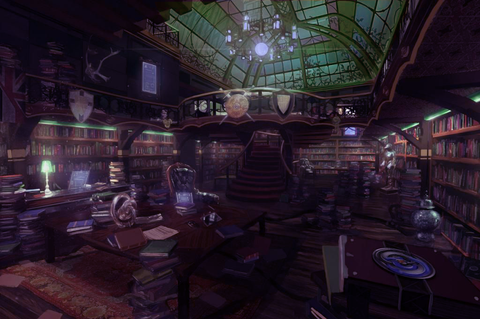

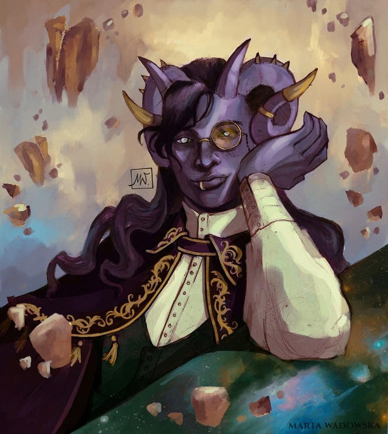

> Alin talks to the tiefling

Alin asks if the tiefling can show them around. They inquire about some books about the makeup of the world. Do they have something about the doomsday gazetteers? They only have gazetteers of different graffendam

> Masq finds a book

A very glossy starry book cover covered in stars, there is a skeleton depicted on it and a red dragon. “The Great Malzdreziret the Scaled Imposter” tale about a red dragon tyrant that lay siege to graddendam in its infancy for decades. The golden swords of gildraeth, lay old marks of the dragon’s breath. Masq notices themselfes sit on a cushioned seat on the second floor, given tea by the tiefling.

> Abraxas looks for a book on half elves in graffendam.

He finds A very small autobiography, pocket sized. It is marked, not for sale and is called. “Of the seven sisters”.

This book is about a high elf from Charneault. At a young age she was sold to the local nobility. It was commonplace for human nobles to extort or otherwise pressure elven families to sell their maidens. For as much as humans hated and were disgusted by elves, they envied them more. To have an elven maiden as a wife for your son meant beautiful or handsome offspring with an ethereal grace, all that was required was mutilation at a young age and an absence of the mother in their lives and you would have a lineage full of beauty and virility. She was bought up by a nobleman for his young son, only for her husband-to-be to perish in the Charneault - Castinella war. Her family in law, stricken with grief, sent her away. Not to her own family or even her own people, but they instead locked her in a tower and cursed her name for the misfortune she had brought upon their household. Here she would wither away for decades as those who had cursed her would perish and the servants who would bring her supplies grew old, had children and were subsequently replaced by those very children. Many of time she had imagined throwing herself from the tower in her grief, and many times she had stepped back inside, too proud and perhaps too hopeful to give in. The people of the town began to forget who she was, and it was several decades later still when a young boy saw the elven lady from the tower and to him, it looked just like a fairytale. When he asked her what she did up there, she answered him in her own tongue, and the boy grew frightened and ran away. He told the town of the lady who dwelled in the overgrown tower, of the lady who might be a living dead. When the townsfolk came upon her and heard her words, they too saw that she was not human; she was clearly a demon straight from the hells.They set her long hair on fire, and in the end it would burn her as well. And she wept and cried, in that language of hers, but none would understand, nor show mercy. She wept until her tongue and eyes were no more, and then only her soul cried out. It wasn’t until much later that she woke up in the arms of someone kind and caring, and her new eyes were still tender and blurry but she saw momentarily a glowing, antlered visage of his elven face.

abraxas recalls this as the skinwalker, father of elves. He’s well over 25k years old, he crafts new bodies to enhabit over and over and over again. At night the skinwaslker will go looking for the impure. Weather wearing a male or female guize, you know them coming with the clinking of throusands of neclases from elves who can no longer be revived for eons to come.

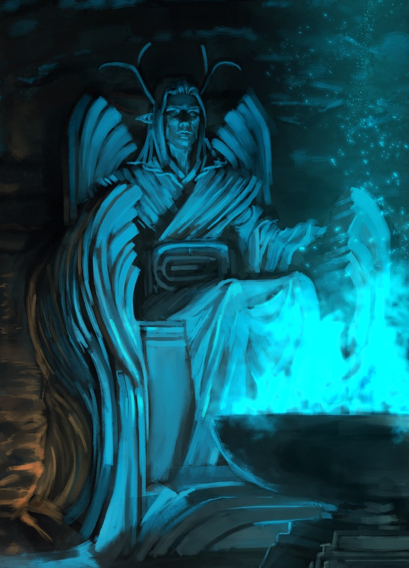

> Tokas looks for artifacts

Aurelias respite, home to the saint who was god touched and pure. Held an item from doctor a robe of celestial grace.

> Unit looks for books on tinkering and making golems

He finds a cast iron cover book on the second floor. A thick book bound in chains within a dome. A manual of iron golems.

How much is the book? This book is impermanent, if you read it it ceases to be, I find that sad. Usually the book simply sits and waits. “I think I will read fantacy and give you an epic quest, then i will give you this quest.”

“I’m Ransdir”

> Alin tries to learn more about the domains of dread

“I do not belive I know of such accounts or books. I have accounts on the incident at Ulmyr’s gate. Oh, you are not familiar. It was some time ago that the city of Ulmyr’s gate ( far nw of here) edge of burag and valikan. A sprawling city of magic. A collection of accounts that took place there, a rift torn into the fabric of reality. The entire city dissapeared. The people within sometimes re-appeared, trapped between worlds.”

Alin learns more about the Disembodied, a race of people stuck between the real and etherial plane.

!What me you to take care of these books? I inherited them and i was happy to stay here unlike my other siblings."

> Abraxas writes notes about the book on parchment.

### Coloss’ boots

We enter the tavern, fitted with huge equipment.

There’s two people of note sitting at the shield table: a halfling woman and a man with the head of a hyena.

Abraxas goes to the bar, the barman is a human male with curly hare and a toothpic.

[figure not shown]

Abraxas buys everyone in the bar a drink, hes earned the people’s favor.

Unit looks through Puppies eyes.

Masq wants to get close to the halfling and hyena, grabbing a drink to get closer.

Annie(the tour guide) claps the hyena on the back, she’s won again. Masq challanges her to a drinking contest.

THe river attached to teh well goes upstream to a tree.

THe pump for the water is in the whitewater temple. Only the speaker can unlock the well anymore. But why would he do that when the well is broken.

The wizard wasn’t that good wirth words, he got a memo to make owlbears, he made owlboars. He loved animals and was vegan.

He wanted to make the perfect creation and he thought lycanthropy was scawy. Did you know he’s a minotaur created by the scientist.

The halfling passes out, alin tries to lesser restoration to get rid of masq’s drunk but is counterspelled by jacky deytona.

## 30

The tour

Alin buys new clothes to be extra fancy.

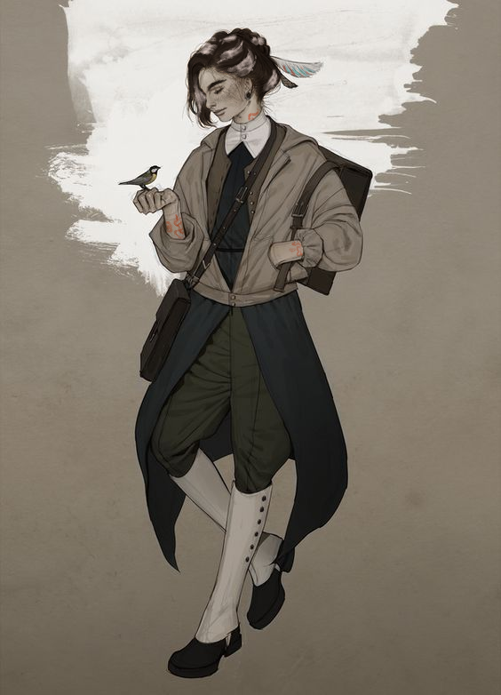

Our guide is Bulrick the minotarur, also known as the minaret of the speaker.

“Dr stein belived that rasising the dead is a thing of the past, dealing with the dead of those that were living means you’re stuck with their bits. Their limitations, He belived that one could enhance creature. Enhancing vision, stealth and even mitochondria, the powerhouse of the cell.”

We’re shown microscopes with growing cells, taught mitosis.

We’re led through the menagerie, full of peculiar creatures.

Hyena creatures were an accident It was dr steins whole wish to make himself the perfect being.

He was terrified of both lycanthropy and vampirism

There’s a large door in the wine cellar, medal chained, with a padlock. The door to the old well.

We finish our tour and go look for the white water temple.

THere’s a large basin of water

Snoring from a man in the side room, he’s woken and we find out this place hasn’t been a temple for generations.

We apolagize for waking him and take our leave.

Masq and tokas re-enter sneaking and lockpick into the boiler room. Creature inside of the pump, made entierly of water.

big red leaver reading ERV

Tokas speaks broken aquan to the creature.

His rage is what keeps the pump going it seems.

DELILAH IS GONE

She’s gone with no word why

only leaving abraxas’ lucky charm

## 31

It is the morning, we go to the whitewater temple.

Masq turns into a dark haired maiden and applies the magical lipstick.

There’s a new person inside the temple, same attire tho.

There’s two people here, Masq asks the older one if he can talk to the other. Upon seeing him Masq gives him a kiss on the cheek, thereby charming the married man.

She brings him to a side room, going to ask him about where the entrance to the underground river is.

Tokas and Unit free the water elemental.

They flee and with the information Masq got from the man we manage to find the enterance to the underground river.

We swim upstream, abraxas, tokas and masq get there in 30min. Alin and Unit take 15 more minutes to get there.

Abraxas manages to climb the well expertly and exit the cover, hiding behind a door when it opens.

He almost manages to be caught as the minotaur and halfling guides enter to retrieve water.

Bulrick decides to double the guard.

Abraxas ties a rope to the well, Masq tries to get up but falls after 10 min, alin does the same but unit makes it up with ease.

They attempt to pull up alin

We manage to all get out of the well, barely.

We go to the second floor. The floor tiles are covered in arrows pointing in various directions. There’s graffity which we decifer with directions.

We decipher which way to go.

We reach the spiral staircase in the end successfully, ascending it the stairs turn into a slipnslide into gunk.

Unit got gunked up on the inside. disadvantage on con checks.

Tokas got web hands, swim speed 20ft 1h.

Masq somehow feels unbothered, psychic resistance 1 week.

Alin and abraxas, laying there they frown. Then the furrow opens up giving them both a third eye, advantage on perception checks, 1 week.

Puppi looks very grumpy, he now has two left feet.

we get to the 3rd floor. What looks like a library and bedchamber. It says floor 8, that doesn’t sound right.

In the middle of the room, on a chalc magic composite creature. The room lights up as we step closer.

From behind a corner steps out a mechanical spider man centaur creature servant. He steps closer and offers his assistance.

a meatball, salmon oatcake and vegetable springroll. The doctor was a Vegan. A strange hand creature with a face and a cape approaches.

He has a gold, platinum and a silver ring. Tokas shakes the silver ring because dr stein hates werewolves.

Theres a bath with grafiti, it sais that dr stein was very benevolant to his bath boys.

## 31

We move up another floor,

The air is fresher, there is wind. could this be a top. A ladder reaches up into pich darkness. “Floor 2” Golden neclace florpion 11 golden rings on the snektopus wand with owl

the sounds of hooves on metal above.

ladder leading up into darkness hooves on metal. Something with heat high above us, high

High levels of magig from all aorund us, probably the same type of magic.

Masq opens the ceiling hatch

We awaken the goose chymera by grabbing the chroma nova.

Hudinki on the roof: “Ah you made it then”

The snaketopus awakens

Abraxas is downed and grappled by the snaketopus, alin gets him up.

We try to escape through the ladder and darkness.

We get out of the tower, hold the hatch shut and escape.

the three eyed fish, various humanoids and we meet larsane

We do the exchange and go our seperate ways

Terrabella lets us step onto a tree.

Tiny light blinking off into the distance, fireworks

All the erkin are there

Larsane’s croma nova glitter bombed thw whole city, it was sparkly and beauty